# DESeq2 Differential Expression Analysis

This weeks Lessons were adapted from https://master.bioconductor.org/packages/release/workflows/vignettes/rnaseqGene/inst/doc/rnaseqGene.html

This week, we’re going to do things a little backwards.

In Lesson 19, we’ll go over the DESeq2 Differential Expression Analysis analysis, and then in Lesson 20 we’ll go back and look at how to perform some Sample QC. If you’re doing Differential Expression analysis, it’s recommended that you perform the QC prior to Differential Expression Analysis.

The reasoning behind doing it this way, is that there is a lot of new libraries, functions, and material so I want to cover the DESeq2 Analysis first before adding in a lot of additional material - sample QC, Gene Clustering, Salmon, tximeta.

# Differential Expression

This is an introduction to RNAseq Differential Expression Analysis involving reading in quantitated gene expression data from an RNA-seq experiment, exploring the data using base R functions and then analysis with the DESeq2 package.

This lesson assumes a basic familiarity with R, data frames, and manipulating data with dplyr and |>.

The Bioinformatics libraries for R are found in [Bioconductor](https://www.bioconductor.org/). To install packages from Bioconductor, you’ll need to install the `BiocManager` package. See the next code section for an example

### Installing Packages from Bioconductor

Please note that there are a lot of packages, that’ll need to be installed for this lesson. It’s recommended to use the Class RStudio Server for this task, as they have already been installed.

```r
install.packages('BiocManager')
BiocManager::install("DESeq2")
library(DESeq2)
```

If you want to install them on your own computer or laptop, you may need to install additional Linux Packages, as well.

## Additional Reading:

1. [Conesa et al. A survey of best practices for RNA-seq data analysis. *Genome Biology* 17:13 (2016)](http://genomebiology.biomedcentral.com/articles/10.1186/s13059-016-0881-8).
2. [Soneson et al. “Differential analyses for RNA-seq: transcript-level estimates improve gene-level inferences.” *F1000Research* 4 (2015)](https://f1000research.com/articles/4-1521/v2).
3. Abstract and introduction sections of [Himes et al. “RNA-Seq transcriptome profiling identifies CRISPLD2 as a glucocorticoid responsive gene that modulates cytokine function in airway smooth muscle cells.” *PLoS ONE* 9.6 (2014): e99625](http://journals.plos.org/plosone/article?id=10.1371/journal.pone.0099625).
4. Review the [*Introduction* (10.1)](http://r4ds.had.co.nz/tibbles.html#introduction-4), [*Tibbles vs. data.frame* (10.3)](http://r4ds.had.co.nz/tibbles.html#tibbles-vs.data.frame), and [*Interacting with Older Code* (10.4)](http://r4ds.had.co.nz/tibbles.html#interacting-with-older-code) sections of the [*R for Data Science* **book**](http://r4ds.had.co.nz/tibbles.html). We will initially be using the `read_*` functions from the [**readr** package](http://readr.tidyverse.org/). These functions load data into a *tibble* instead of R’s traditional data.frame. Tibbles are data frames, but they tweak some older behaviors to make life a little easier. These sections explain the few key small differences between traditional data.frames and tibbles.

## Exploring the Dataset

We’ll load `Tidyverse` to load the *tibbles* and load the sample data. Remember, the data for this lesson comes from:

> Himes *et al*. “RNA-Seq Transcriptome Profiling Identifies CRISPLD2 as a Glucocorticoid Responsive Gene that Modulates Cytokine Function in Airway Smooth Muscle Cells.” *PLoS ONE*. [2014 Jun 13;9(6):e99625](http://journals.plos.org/plosone/article?id=10.1371/journal.pone.0099625). PMID: 24926665.

They had 8 total samples - 4 different airway smooth muscle cell lines which each has a sample that was untreated and treated with Dexamethasone.

```r
library(tidyverse)
# read in sample info
sampleData <- read_csv('sample_info.csv', col_names = TRUE)
sampleData
```

| sample | cellLine | dexamethasone |
| --- | --- | --- |
| SRR1039508 | N61311 | untreated |
| SRR1039509 | N61311 | treated |
| SRR1039512 | N052611 | untreated |
| SRR1039513 | N052611 | treated |
| SRR1039516 | N080611 | untreated |
| SRR1039517 | N080611 | treated |
| SRR1039520 | N061011 | untreated |
| SRR1039521 | N061011 | treated |

The first column is the NCBI Sequence Read Archive Accession Number for the sequence sample. Go to [NCBI SRA](https://www.ncbi.nlm.nih.gov/sra) and search for *SRR1039508* and *SRR1039509*. What information is provided about the sequence? Does it match what you have in your *sampleData*

# Importing the Counts Data

```r
countsData <- read_csv('counts_data.csv',col_names=TRUE)
countsData
```

| ensgene | SRR1039508 | SRR1039509 | SRR1039512 | SRR1039513 | SRR1039516 | SRR1039517 | SRR1039520 | SRR1039521 |
| --- | --- | --- | --- | --- | --- | --- | --- | --- |
| ENSG00000000003 | 679 | 448 | 873 | 408 | 1138 | 1047 | 770 | 572 |
| ENSG00000000005 | 0 | 0 | 0 | 0 | 0 | 0 | 0 | 0 |
| ENSG00000000419 | 467 | 515 | 621 | 365 | 587 | 799 | 417 | 508 |
| ENSG00000000457 | 260 | 211 | 263 | 164 | 245 | 331 | 233 | 229 |
| ENSG00000000460 | 60 | 55 | 40 | 35 | 78 | 63 | 76 | 60 |
| ENSG00000000938 | 0 | 0 | 2 | 0 | 1 | 0 | 0 | 0 |
| ENSG00000000971 | 3251 | 3679 | 6177 | 4252 | 6721 | 11027 | 5176 | 7995 |
| ENSG00000001036 | 1433 | 1062 | 1733 | 881 | 1424 | 1439 | 1359 | 1109 |
| ENSG00000001084 | 519 | 380 | 595 | 493 | 820 | 714 | 696 | 704 |
| ENSG00000001167 | 394 | 236 | 464 | 175 | 658 | 584 | 360 | 269 |

[output cut: 990 more lines]

The Counts data was generated by aligning the FASTQ reads to the transcriptome and counting how many reads mapped to each gene. The first column of *ensgene* is the Ensembl Gene Accession. Goto [Ensembl](https://useast.ensembl.org/) and search for *ENSG00000000003*, what gene is the is the accession for? What information is provided about the gene on Ensembl?

## RNASeq and Low Counts Data

One important fact about RNASeq Data is that a lot of counts may be close to zero. To look at this, let’s use *mutate* to create a new column called *controlmean* and *treatedmean*.

| ensgene | SRR1039508 | SRR1039509 | SRR1039512 | SRR1039513 | SRR1039516 | SRR1039517 | SRR1039520 | SRR1039521 | controlmean | treatedmean |
| --- | --- | --- | --- | --- | --- | --- | --- | --- | --- | --- |
| ENSG00000000003 | 679 | 448 | 873 | 408 | 1138 | 1047 | 770 | 572 | 865.00 | 618.75 |
| ENSG00000000005 | 0 | 0 | 0 | 0 | 0 | 0 | 0 | 0 | 0.00 | 0.00 |
| ENSG00000000419 | 467 | 515 | 621 | 365 | 587 | 799 | 417 | 508 | 523.00 | 546.75 |
| ENSG00000000457 | 260 | 211 | 263 | 164 | 245 | 331 | 233 | 229 | 250.25 | 233.75 |
| ENSG00000000460 | 60 | 55 | 40 | 35 | 78 | 63 | 76 | 60 | 63.50 | 53.25 |
| ENSG00000000938 | 0 | 0 | 2 | 0 | 1 | 0 | 0 | 0 | 0.75 | 0.00 |
| ENSG00000000971 | 3251 | 3679 | 6177 | 4252 | 6721 | 11027 | 5176 | 7995 | 5331.25 | 6738.25 |
| ENSG00000001036 | 1433 | 1062 | 1733 | 881 | 1424 | 1439 | 1359 | 1109 | 1487.25 | 1122.75 |
| ENSG00000001084 | 519 | 380 | 595 | 493 | 820 | 714 | 696 | 704 | 657.50 | 572.75 |
| ENSG00000001167 | 394 | 236 | 464 | 175 | 658 | 584 | 360 | 269 | 469.00 | 316.00 |

[output cut: 990 more lines]

We can plot a histogram or distribution plot of the values.

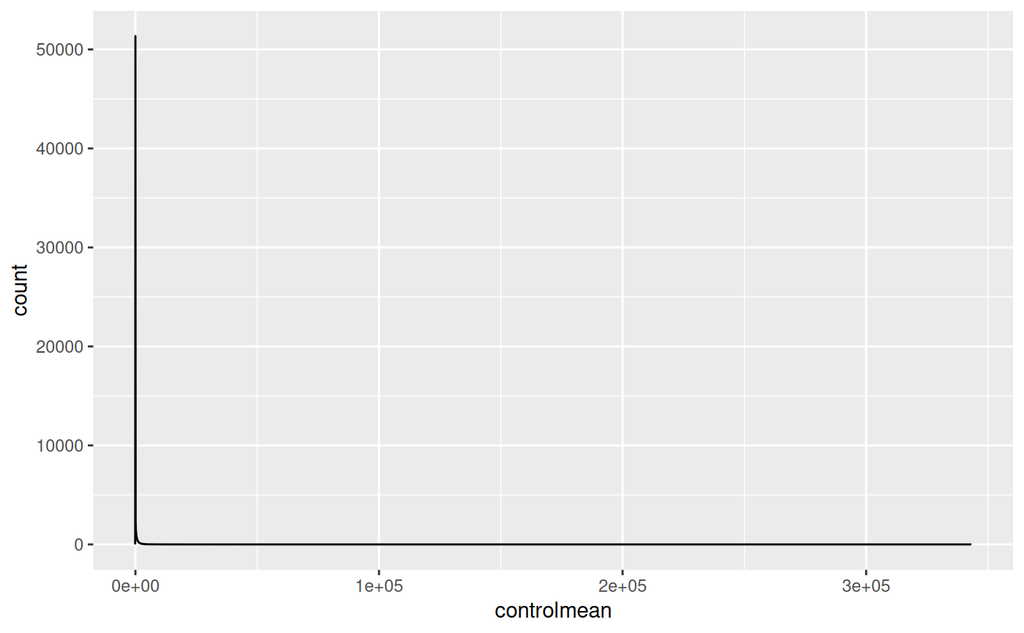

We see that there are a lot of low counts. We’ll need to take care of this later

We read the Tables in as Tibbles, but DESeq2 requires R *data.frame* datatypes. Let’s convert them to *data.frame* and verify that they are the correct datatype

```r
countsData <- as.data.frame(countsData)
sampleData <- as.data.frame(sampleData)
head(countsData)
```

|  | ensgene | SRR1039508 | SRR1039509 | SRR1039512 | SRR1039513 | SRR1039516 | SRR1039517 | SRR1039520 | SRR1039521 |
| --- | --- | --- | --- | --- | --- | --- | --- | --- | --- |
| 1 | ENSG00000000003 | 679 | 448 | 873 | 408 | 1138 | 1047 | 770 | 572 |
| 2 | ENSG00000000005 | 0 | 0 | 0 | 0 | 0 | 0 | 0 | 0 |
| 3 | ENSG00000000419 | 467 | 515 | 621 | 365 | 587 | 799 | 417 | 508 |
| 4 | ENSG00000000457 | 260 | 211 | 263 | 164 | 245 | 331 | 233 | 229 |
| 5 | ENSG00000000460 | 60 | 55 | 40 | 35 | 78 | 63 | 76 | 60 |
| 6 | ENSG00000000938 | 0 | 0 | 2 | 0 | 1 | 0 | 0 | 0 |

```r
head(sampleData)
```

|  | sample | cellLine | dexamethasone |
| --- | --- | --- | --- |
| 1 | SRR1039508 | N61311 | untreated |
| 2 | SRR1039509 | N61311 | treated |
| 3 | SRR1039512 | N052611 | untreated |
| 4 | SRR1039513 | N052611 | treated |
| 5 | SRR1039516 | N080611 | untreated |
| 6 | SRR1039517 | N080611 | treated |

```r
class(countsData)
class(sampleData)
```

Are they both *data.frame* datatypes?

## Quick QCing our Tables Order

DESeq expects that the rows of *sampleData* are in the same order as the *countsData*.

We need to check that verify that our *countsData* columns are in the same order as our *sampleData* columns. To get the column names of the *countsData* we can use *names()*.

```r
names(countsData)
```

We’ll want to exclude the the first column name because this isn’t one of the samples. To exclude the first item in the character vector, we can use negative indexing.

```r
names(countsData)[-1]
```

```r
sampleData$sample
```

```r
all(names(countsData)[-1]==sampleData$sample)
```

## Constructing the DESeq2 Object

```r
library(DESeq2)
dds <- DESeqDataSetFromMatrix(countData = ...,  # Counts Data
                              colData = ...,  # Sample Data
                              design = ~ ..., # Grouping or Treatment
                              tidy=TRUE   # If First column of Counts Data is the Row Names for Counts
                              )
```

```r
library(DESeq2)
dds <- DESeqDataSetFromMatrix(countData = countsData,
                              colData = sampleData,
                              design = ~ cellLine + dexamethasone,
                              tidy=TRUE
                              )

dds
```

If the columns, supplied to the design argument aren’t *factors*, they’ll be converted to *factors*. The `rownames(...)` describes the number and names used for the rows.

How many genes are there represented in this dataset?

What type of an object is the DESeq2 object?

```r
class(dds)
typeof(dds)
```

**More on S4:**

- [S4 Geeks for Geeks](https://www.geeksforgeeks.org/r-s4-class/)
- [S4: Advanced R](https://adv-r.hadley.nz/s4.html)

Notice that it stores the Sample Data, Counts Data, and Design.

## Filtering out Low Counts

Our count matrix contains many rows with only zeros, and additionally many rows with only a few fragments total. In order to reduce the size of the object, and to increase the speed of our functions, we can remove the rows that have no or nearly no information about the amount of gene expression.

```r
nrow(dds)
#smallestGroupSize <- 4
keep <- rowSums(counts(dds) >= 10) #>= smallestGroupSize
dds <- dds[keep,]
nrow(dds)
```

## Ensuring our Reference Group is Properly Set

**Note:** it is prefered in R that the first level of a factor be the reference level (e.g. control, or untreated samples). In this case, when the `sampleData` table was assembled the treated samples were set as the reference, but we want the untreated as reference. Therefore, we need to use *relevel* as shown below.

*relevel* is a function, which decides how the variables will be coded, and how contrasts will be computed. For a two-group comparison, the use of *relevel* to change the reference level would flip the sign of a coefficient associated with a contrast between the two groups.

```r
dds$dexamethasone <- relevel(dds$dexamethasone, ref = "untreated")
dds$dexamethasone
```

## Running DESeq Differential Expression Analysis

Once we’ve ensured our counts are filtered and levels are in the correct order, we are ready to run DESeq2 analysis.

To run the analysis, we need to pass the *DESeqDataset* to the `DESeq()` function. This will estimate the size factors, the dispersion, fit a model to the counts and finally perform the hypothesis tests. The results are stored back in the *DESeqDataset*.

```r
dds <- DESeq(dds)
```

To get the results table, we need to use the `results()` function to extracts a result table from the DESeq analysis giving columns for the base means across samples, log2 fold changes, standard errors, test statistics, p-value, and adjusted p-value.

```r
res <- results(dds)

res
```

The first column, `baseMean`, is a just the average of the normalized count values, divided by the size factors, taken over all samples in the *DESeqDataSet*. The remaining four columns refer to a specific contrast, namely the comparison of the `treated` level over the `untreated` level for the factor variable `dexamethasone`.

The column `log2FoldChange` is the effect size estimate. It tells us how much the gene’s expression seems to have changed due to treatment with dexamethasone in comparison to untreated samples. This value is reported on a logarithmic scale to base 2: for example, a log2 fold change of 1.5 means that the gene’s expression is increased by a multiplicative factor of $2^{1.5} \approx 2.82$.

Of course, this estimate has an uncertainty associated with it, which is available in the column `lfcSE`, the standard error estimate for the log2 fold change estimate. We can also express the uncertainty of a particular effect size estimate as the result of a statistical test. The purpose of a test for differential expression is to test whether the data provides sufficient evidence to conclude that this value is really different from zero. *DESeq2* performs for each gene a *hypothesis test* to see whether evidence is sufficient to decide against the *null hypothesis* that there is zero effect of the treatment on the gene and that the observed difference between treatment and control was merely caused by experimental variability (i.e., the type of variability that you can expect between different samples in the same treatment group). As usual in statistics, the result of this test is reported as a *p* value, and it is found in the column `pvalue`. Remember that a *p* value indicates the probability that a fold change as strong as the observed one, or even stronger, would be seen under the situation described by the null hypothesis.

We can also summarize the results with the following line of code, which reports some additional information, that will be covered in later sections.

## Exploring the Results of DESeq2 Analysis

```r
summary(res)
```

- lower the false discovery rate threshold (the threshold on `padj` in the results table)
- raise the log2 fold change threshold from 0 using the `lfcThreshold` argument of *results*

If we lower the false discovery rate threshold, we should also inform the `results()` function about it, so that the function can use this threshold for the optimal independent filtering that it performs:

To change the FDR alpha p-value cutoff value, you can use the *results()* function to specify an *alpha* new cutoff value.

```r
res0.01 <- results(dds, alpha = 0.01)
summary(res0.01)
```

If we want to raise the log2 fold change threshold, so that we test for genes that show more substantial changes due to treatment, we simply supply a value on the log2 scale. For example, by specifying `lfcThreshold = 1`, we test for genes that show significant effects of treatment on gene counts more than doubling or less than halving, because $2^1 = 2$.

```r
resLFC1 <- results(dds, lfcThreshold=1)
table(resLFC1$padj < 0.1)
```

## Multiple testing

In high-throughput biology, we are careful to not use the *p* values directly as evidence against the null, but to correct for *multiple testing*.

What would happen if we were to simply threshold the *p* values at a low value, say 0.05?

```r
sum(res$pvalue < 0.05, na.rm=TRUE)
sum(!is.na(res$pvalue))
```

Now, assume for a moment that the null hypothesis is true for all genes, i.e., no gene is affected by the treatment with dexamethasone. Then, by the definition of the *p* value, we expect up to 5% of the genes to have a *p* value below 0.05. This amounts to 807 genes. If we just considered the list of genes with a *p* value below 0.05 as differentially expressed, this list should therefore be expected to contain up to 807 / 1821 = 44% false positives.

```r
sum(!is.na(res$pvalue))*.05 / sum(res$pvalue < .05, na.rm=TRUE) * 100
```

*DESeq2* uses the Benjamini-Hochberg (BH) adjustment [@Benjamini1995Controlling] as implemented in the base R *p.adjust* function; in brief, this method calculates for each gene an adjusted *p* value that answers the following question: if one called significant all genes with an adjusted *p* value less than or equal to this gene’s adjusted *p* value threshold, what would be the fraction of false positives (the *false discovery rate*, FDR) among them, in the sense of the calculation outlined above? These values, called the BH-adjusted *p* values, are given in the column `padj` of the `res` object.

The FDR is a useful statistic for many high-throughput experiments, as we are often interested in reporting or focusing on a set of interesting genes, and we would like to put an upper bound on the percent of false positives in this set.

Hence, if we consider a fraction of 10% false positives acceptable, we can consider all genes with an adjusted *p* value below 10% = 0.1 as significant. How many such genes are there?

```r
sum(res$padj < 0.1, na.rm=TRUE)
```

We subset the results table to these genes and then sort it by the log2 fold change estimate to get the significant genes with the strongest down-regulation:

```r
resSig <- subset(res, padj < 0.1)
head(resSig[ order(resSig$log2FoldChange), ])
```

…and with the strongest up-regulation:

```r
head(resSig[ order(resSig$log2FoldChange, decreasing = TRUE), ])
```

# Plotting results

## Counts plot

```r
topGene <- rownames(res)[which.min(res$padj)]
plotCounts(dds, gene = topGene, intgroup=c("dexamethasone"))
```

[output not shown]

```r
library("ggbeeswarm")
geneCounts <- plotCounts(dds, gene = topGene, intgroup = c("dexamethasone","cellLine"),
                         returnData = TRUE)
ggplot(geneCounts, aes(x = dexamethasone, y = count, color = cellLine)) +
  scale_y_log10() +  geom_beeswarm(cex = 3)
```

[output not shown]

```r
ggplot(geneCounts, aes(x = dexamethasone, y = count, color = cellLine, group = cellLine)) +
  scale_y_log10() + geom_point(size = 3) + geom_line()
```

[output not shown]

## MA-plot

An *MA-plot* [@Dudoit2002Statistical] provides a useful overview for the distribution of the estimated coefficients in the model, e.g. the comparisons of interest, across all genes. On the y-axis, the “M” stands for “minus” – subtraction of log values is equivalent to the log of the ratio – and on the x-axis, the “A” stands for “average”. You may hear this plot also referred to as a mean-difference plot, or a Bland-Altman plot.

```r
library("apeglm")
resultsNames(dds)
res <- lfcShrink(dds, coef="cellLine_N061011_vs_N052611", type="apeglm")
plotMA(res, ylim = c(-5, 5))
```

[output not shown]

```r
res
```

If it is necessary to specify a contrast not represented in `resultsNames(dds)`, either of the other two shrinkage methods can be used, or in some cases, re-factoring the relevant variables and running `nbinomWaldTest` followed by `lfcShrink` is sufficient. See the DESeq2 vignette for more details.

```r
res.noshr <- results(dds, name="dexamethasone_treated_vs_untreated")
plotMA(res.noshr, ylim = c(-5, 5))
```

[output not shown]

We can label individual points on the MA-plot as well. Here we use the *with* R function to plot a circle and text for a selected row of the results object. Within the *with* function, only the `baseMean` and `log2FoldChange` values for the selected rows of `res` are used.

```r
plotMA(res, ylim = c(-5,5))
topGene <- rownames(res)[which.min(res$padj)]
with(res[topGene, ], {
  points(baseMean, log2FoldChange, col="dodgerblue", cex=2, lwd=2)
  text(baseMean, log2FoldChange, topGene, pos=2, col="dodgerblue")
})
```

[output not shown]

```r
hist(res$pvalue[res$baseMean > 1], breaks = 0:20/20,
     col = "grey50", border = "white")
```

[output not shown]

## Volcano Plot

```r
#reset par
par(mfrow=c(1,1))
# Make a basic volcano plot
with(res, plot(log2FoldChange, -log10(pvalue), pch=20, main="Volcano plot", xlim=c(-5,5)))

# Add colored points: blue if padj<0.01, red if log2FC>1 and padj<0.05)
with(subset(res, padj<.01 ), points(log2FoldChange, -log10(pvalue), pch=20, col="blue"))
with(subset(res, padj<.01 & abs(log2FoldChange)>2), points(log2FoldChange, -log10(pvalue), pch=20, col="red"))
```

[output not shown]

```r
library(EnhancedVolcano)
EnhancedVolcano(res,
    lab = rownames(res),
    x = 'log2FoldChange',
    y = 'padj')
```

[output not shown]

## Independent filtering

```r
qs <- c(0, quantile(resLFC1$baseMean[resLFC1$baseMean > 0], 0:6/6))
bins <- cut(resLFC1$baseMean, qs)
levels(bins) <- paste0("~", round(signif((qs[-1] + qs[-length(qs)])/2, 2)))
fractionSig <- tapply(resLFC1$pvalue, bins, function(p)
                          mean(p < .05, na.rm = TRUE))
barplot(fractionSig, xlab = "mean normalized count",
                     ylab = "fraction of small p values")
```

[output not shown]

At first sight, there may seem to be little benefit in filtering out these genes. After all, the test found them to be non-significant anyway. However, these genes have an influence on the multiple testing adjustment, whose performance improves if such genes are removed. By removing the low count genes from the input to the FDR procedure, we can find more genes to be significant among those that we keep, and so improved the power of our test. This approach is known as *independent filtering*.

The *DESeq2* software automatically performs independent filtering that maximizes the number of genes with adjusted *p* value less than a critical value (by default, `alpha` is set to 0.1). This automatic independent filtering is performed by, and can be controlled by, the *results* function.

The term *independent* highlights an important caveat. Such filtering is permissible only if the statistic that we filter on (here the mean of normalized counts across all samples) is independent of the actual test statistic (the *p* value) under the null hypothesis. Otherwise, the filtering would invalidate the test and consequently the assumptions of the BH procedure. The independent filtering software used inside *DESeq2* comes from the *genefilter* package, that contains a reference to a paper describing the statistical foundation for independent filtering [@Bourgon2010Independent].

## Annotating and exporting results

Our result table so far only contains the Ensembl gene IDs, but alternative gene names may be more informative for interpretation. Bioconductor’s annotation packages help with mapping various ID schemes to each other. We load the *AnnotationDbi* package and the annotation package *org.Hs.eg.db*:

```r
library("AnnotationDbi")
library("org.Hs.eg.db")
```

This is the organism annotation package (“org”) for *Homo sapiens* (“Hs”), organized as an *AnnotationDbi* database package (“db”), using Entrez Gene IDs (“eg”) as primary key. To get a list of all available key types, use:

```r
columns(org.Hs.eg.db)
```

We can use the *mapIds* function to add individual columns to our results table. We provide the row names of our results table as a key, and specify that `keytype=ENSEMBL`. The `column` argument tells the *mapIds* function which information we want, and the `multiVals` argument tells the function what to do if there are multiple possible values for a single input value. Here we ask to just give us back the first one that occurs in the database. To add the gene symbol and Entrez ID, we call *mapIds* twice.

```r
ens.str <- substr(rownames(res), 1, 15)
res$symbol <- mapIds(org.Hs.eg.db,
                     keys=ens.str,
                     column="SYMBOL",
                     keytype="ENSEMBL",
                     multiVals="first")
res$entrez <- mapIds(org.Hs.eg.db,
                     keys=ens.str,
                     column="ENTREZID",
                     keytype="ENSEMBL",
                     multiVals="first")
```

Now the results have the desired external gene IDs:

```r
resOrdered <- res[order(res$pvalue),]
head(resOrdered)
```

## Exporting results

```r
resOrderedDF <- as.data.frame(resOrdered)
write.csv(resOrderedDF, file = "results.csv")
```